# What We Watched: Netflix Viewership and the 2027 Content Strategy

Author

Nuzat Chowdhury

**load_netflix_data() — instructor-provided function**

```r
load_netflix_data <- function(){
  library(tidyverse); library(rvest); library(readxl); library(fs)
  data_dir <- path("data", "mp01")
  if(!dir_exists(data_dir)) dir_create(data_dir, showWarnings=FALSE, recurse=TRUE)
  NETFLIX_URLS <- list(
    `2023H1` = "https://about.netflix.com/news/what-we-watched-a-netflix-engagement-report",
    `2023H2` = "https://about.netflix.com/news/what-we-watched-the-second-half-of-2023",
    `2024H1` = "https://about.netflix.com/news/what-we-watched-the-first-half-of-2024",
    `2024H2` = "https://about.netflix.com/news/what-we-watched-the-second-half-of-2024",
    `2025H1` = "https://about.netflix.com/news/what-we-watched-the-first-half-of-2025",
    `2025H2` = "https://about.netflix.com/news/what-we-watched-the-second-half-of-2025",
    `2026H1` = "https://about.netflix.com/news/what-we-watched-the-first-half-of-2026"
  )
  download_if_needed <- function(url, local){
    if(!file_exists(local)) download.file(url, local, quiet = TRUE, mode = "wb")
    return(local)
  }
  NETFLIX_URLS |>
    map(read_html) |>
    map(html_element, xpath = "//a[contains(@href, '.xlsx')]") |>
    map_chr(html_attr, "href") |>
    enframe("period", "url") |>
    mutate(path = path(data_dir, paste0(period, ".xlsx")),
           path = map2(url, path, download_if_needed),
           data = map(path, read_excel, skip=3, na="*"),
           data = map(data, \(x) x |> mutate(`Release Date` = as.Date(`Release Date`)))) |>
    unnest(data) |>
    select(-url, -path) |>
    mutate(year=str_sub(period, 1, 4),
           half=str_sub(period, start=6),
           period_start = make_date(year, if_else(half==1, 1, 7), 1),
           period_end = make_date(year, if_else(half==1, 6, 12), if_else(half==1, 30, 31))) |>
    filter(!is.na(`Hours Viewed`)) |>
    mutate(live_event = !is.na(Runtime) & str_detect(Runtime, "\\d+:\\d+\\*"),
           clean_time = str_remove(Runtime, fixed("*")),
           Runtime = 60 * hour(hm(clean_time)) + minute(hm(clean_time))) |>
    select(-clean_time) |>
    mutate(Runtime = coalesce(Runtime, mean(Runtime, na.rm=TRUE)), .by=Title,
           Title = stringi::stri_trans_general(Title, "Latin-ASCII"),
           Title = str_remove(Title, " // .*"),
           Title = str_remove(Title, "[^[:ascii:]].*"),
           Title = str_trim(Title)) |>
    filter_out(Title == "") |>
    select(year, period, period_start, period_end, Title, -half,
           Runtime, Views, `Hours Viewed`, `Release Date`,
           `Available Globally?`, live_event)
}
```

**Task 1–3: Acquire, rename, and type-cast**

```r
NETFLIX_DATA <- load_netflix_data() |>
  rename(
    title              = Title,
    runtime            = Runtime,
    views              = Views,
    hours_viewed       = `Hours Viewed`,
    release_date       = `Release Date`,
    available_globally = `Available Globally?`
  ) |>
  mutate(
    year               = as.integer(year),
    available_globally = available_globally == "Yes",
    available_globally = coalesce(available_globally, FALSE)
  ) |>
  mutate(
    is_show = str_detect(title, regex("season", ignore_case = TRUE)) |
              (runtime > 240 & !is.na(runtime))
  )
```

## Introduction

Netflix publishes a semiannual “What We Watched” (WWW) engagement report disclosing aggregate viewership for nearly its entire global catalog. Since the first report (2023H1), seven consecutive periods of data have been released, spanning January 2023 through June 2026. This report uses those seven reports to identify what types of content actually capture Netflix watch time, and to derive specific, evidence-based recommendations for the 2027 original-content budget. The analysis is presented as a corporate strategy memo; supporting calculations and two appendices (a Gini coefficient analysis and a data visualization) follow.

## Strategy Memo: 2027 Original Content Priorities

**MEMORANDUM**

**TO:** Netflix Content Strategy Leadership **FROM:** Content Analytics **DATE:** October 2026 **RE:** Evidence-based priorities for the 2027 originals budget

### Executive Summary

Analysis of seven consecutive WWW reporting periods (2023H1–2026H1) yields three strategic conclusions for the 2027 budget: **concentrate capital on a small set of durable global franchises, wind down regional licensing, and treat both movies and live events as narrow instruments rather than growth pillars.**

### 1. The long tail is winning — and that changes the strategy

No individual title dominates Netflix. The single most-watched title in any period captured only **0.9% to 1.4%** of that period’s total watch time. In 2026H1, the top ten titles combined captured just **6.7%**. Meanwhile the reported catalog grew **24%** between 2023H2 and 2026H1, while the average title’s watch time declined **-7.8%**.

**Recommendation:** For 2027, shift a larger share of the originals budget toward continuation seasons and franchise extensions of proven properties, and reduce the number of standalone new-IP greenlights.

### 2. Global originals outperform regional licensing roughly 2:1

Only **23.8%** of reported titles are available in all Netflix territories, yet those titles capture **51.9%** of all watch time — a **2.2×** over-representation relative to their catalog share.

**Recommendation:** Continue reallocating budget from regional licensing toward globally-released originals.

### 3. Shows are the business; movies are a retention feature

Excluding the 2023H1 methodological outlier, episodic content captured approximately **95.4%** of watch time across all periods; films accounted for only **4.6%**. Median runtime per title was flat between 5.2 and 5.5 hours, so this is not a shift toward shorter “bite-sized” content — it is a durable structural preference for series.

**Recommendation:** Maintain a lean flagship-movie slate (~12–15 titles/year) sufficient to serve subscribers who choose Netflix for movie nights. Do not expand movie spend.

### 4. Live events: high peaks, thin middle

Live events represent only **0.50%** of reported titles (310 of 61,892), but the top live event — *Jake Paul vs. Mike Tyson* — drew 236M hours, exceeding every film in the dataset. The second-place live event drew only 24.4M hours — a **90% cliff**.

**Recommendation:** Treat live events as a targeted, opportunistic instrument, not a strategic pillar. Fund only marquee events with established cultural gravity.

### Bottom Line for 2027

| Priority | Action |
| --- | --- |
| Franchises | Grow investment in proven multi-season properties |
| Global originals | Increase share; wind down regional licensing |
| Movies | Hold at current cadence; do not expand |
| Live events | Fund only proven marquee events |

Netflix’s durable advantage is not finding the next single mega-hit — no title captures more than 1.4% of period watch time. It is sustaining global franchises that reliably command outsized attention period after period. The 2027 budget should reflect that.

## Data Acquisition and Preparation

The instructor-provided `load_netflix_data()` function (Task 1) acquires and standardizes all seven WWW reports directly from Netflix’s corporate newsroom, caching local copies under `data/mp01/` to avoid redundant downloads. I then applied two additional cleaning steps:

- **Task 2 (rename):** converted the raw column names (`Title`, `Runtime`, `Views`, `Hours Viewed`, `Release Date`, `Available Globally?`) into tidy snake_case names (`title`, `runtime`, `views`, `hours_viewed`, `release_date`, `available_globally`).
- **Task 3 (type):** coerced `year` from character to integer, and `available_globally` from `"Yes"`/`"No"` strings to logical `TRUE`/`FALSE`. Two rows with missing values were set to `FALSE` on the assumption that unknown availability is more likely regional than global.

After cleaning, `NETFLIX_DATA` contains **61,892 rows and 12 columns**.

### Task 4: Initial EDA pass

```r
glimpse(NETFLIX_DATA)
```

```
Rows: 61,892
Columns: 12
$ year               <int> 2023, 2023, 2023, 2023, 2023, 2023, 2023, 2023, 202…
$ period             <chr> "2023H1", "2023H1", "2023H1", "2023H1", "2023H1", "…
$ period_start       <date> 2023-01-01, 2023-01-01, 2023-01-01, 2023-01-01, 20…
$ period_end         <date> 2023-06-30, 2023-06-30, 2023-06-30, 2023-06-30, 20…
$ title              <chr> "The Night Agent: Season 1", "Ginny & Georgia: Seas…
$ runtime            <dbl> 491, 587, 856, 409, 389, 497, 2703, 533, 548, 428, …
$ views              <dbl> NA, NA, NA, NA, NA, NA, NA, NA, NA, NA, NA, NA, NA,…
$ hours_viewed       <dbl> 812100000, 665100000, 622800000, 507700000, 5030000…
$ release_date       <date> 2023-03-23, 2023-01-05, 2022-12-30, 2022-11-23, 20…
$ available_globally <lgl> TRUE, TRUE, TRUE, TRUE, TRUE, TRUE, FALSE, TRUE, TR…
$ live_event         <lgl> FALSE, FALSE, FALSE, FALSE, FALSE, FALSE, FALSE, FA…
$ is_show            <lgl> TRUE, TRUE, TRUE, TRUE, TRUE, TRUE, TRUE, TRUE, TRU…
```

```r
skim(NETFLIX_DATA)
```

Data summary

| Name | NETFLIX_DATA |
| --- | --- |
| Number of rows | 61892 |
| Number of columns | 12 |
| _______________________ |  |
| Column type frequency: |  |
| character | 2 |
| Date | 3 |
| logical | 3 |
| numeric | 4 |
| ________________________ |  |
| Group variables | None |

**Variable type: character**

| skim_variable | n_missing | complete_rate | min | max | empty | n_unique | whitespace |
| --- | --- | --- | --- | --- | --- | --- | --- |
| period | 0 | 1 | 6 | 6 | 0 | 7 | 0 |
| title | 0 | 1 | 1 | 217 | 0 | 24427 | 0 |

**Variable type: Date**

| skim_variable | n_missing | complete_rate | min | max | median | n_unique |
| --- | --- | --- | --- | --- | --- | --- |
| period_start | 0 | 1.00 | 2023-01-01 | 2026-01-01 | 2024-01-01 | 7 |
| period_end | 0 | 1.00 | 2023-06-30 | 2026-06-30 | 2024-06-30 | 7 |
| release_date | 35251 | 0.43 | 2010-04-01 | 2026-06-29 | 2021-06-17 | 2487 |

**Variable type: logical**

| skim_variable | n_missing | complete_rate | mean | count |
| --- | --- | --- | --- | --- |
| available_globally | 0 | 1 | 0.35 | FAL: 40173, TRU: 21719 |
| live_event | 0 | 1 | 0.01 | FAL: 61582, TRU: 310 |
| is_show | 0 | 1 | 0.71 | TRU: 44196, FAL: 17696 |

**Variable type: numeric**

| skim_variable | n_missing | complete_rate | mean | sd | p0 | p25 | p50 | p75 | p100 | hist |
| --- | --- | --- | --- | --- | --- | --- | --- | --- | --- | --- |
| year | 0 | 1.00 | 2024.11 | 1.08 | 2023 | 2023 | 2024 | 2025 | 2026 | ▇▅▁▅▂ |
| runtime | 13085 | 0.79 | 467.35 | 694.71 | 2 | 210 | 320 | 545 | 23853 | ▇▁▁▁▁ |
| views | 18198 | 0.71 | 1375241.45 | 3630933.22 | 100000 | 100000 | 400000 | 1200000 | 144800000 | ▇▁▁▁▁ |
| hours_viewed | 0 | 1.00 | 8265858.27 | 24924226.03 | 100000 | 500000 | 1800000 | 6400000 | 964100000 | ▇▁▁▁▁ |

## Task 5: Exploratory Questions — Inline Answers

**1. What date range is covered?** The data spans **2023-01-01** through **2026-06-30** — seven consecutive 6-month periods.

**2. How many distinct titles?** **24,427** distinct titles appear across all periods (some appear in multiple periods, so the 61,892 rows represent “title-period” pairs).

**3. Total hours viewing the Bridgerton universe?**

```r
NETFLIX_DATA |>
  filter(str_detect(title, "Bridgerton")) |>
  summarize(total = sum(hours_viewed))
```

```
# A tibble: 1 × 1
       total
       <dbl>
1 4862800000
```

The Bridgerton universe accumulated **4,862,800,000** hours of watch time.

**4. Total hours viewing the five real Stranger Things seasons?**

```r
NETFLIX_DATA |>
  filter(str_detect(title, "Stranger Things")) |>
  filter_out(str_detect(title, "Beyond")) |>
  filter_out(str_detect(title, "Tales")) |>
  filter_out(str_detect(title, "Fireplace")) |>
  summarize(total = sum(hours_viewed))
```

```
# A tibble: 1 × 1
       total
       <dbl>
1 5548500000
```

After excluding the three companion shows, the five main seasons accumulated **5,548,500,000** hours.

**5. What fraction of 2026H1 watch time was captured by the top 10 titles?** The top 10 titles in 2026H1 captured **6.7%** of total period watch time.

**6. Fraction of catalog globally available?** Globally available content represents **23.8%** of catalog titles, but **51.9%** of total hours watched — a **2.2×** over-representation by watch time.

## Task 6: Table-Based Explorations

### T6.1 — Top Title by Watch Time, by Period

```r
top_per_period <- NETFLIX_DATA |>
  group_by(period) |>
  mutate(period_total = sum(hours_viewed)) |>
  slice_max(hours_viewed, n = 1, with_ties = FALSE) |>
  ungroup() |>
  transmute(
    Period      = period,
    Title       = title,
    `Hours (B)` = hours_viewed / 1e9,
    Share       = hours_viewed / period_total
  )

top_per_period |>
  gt() |>
  fmt_number(columns = `Hours (B)`, decimals = 2) |>
  fmt_percent(columns = Share, decimals = 1) |>
  cols_label(`Hours (B)` = "Hours Viewed (Billions)") |>
  tab_header(title = "Top Title by Watch Time, by Period",
             subtitle = "2023H1 – 2026H1") |>
  tab_source_note(source_note = "Source: Netflix 'What We Watched' engagement reports.")
```

Top Title by Watch Time, by Period

2023H1 – 2026H1

| Period | Title | Hours Viewed (Billions) | Share |
| --- | --- | --- | --- |
| 2023H1 | The Night Agent: Season 1 | 0.81 | 0.9% |
| 2023H2 | King the Land: Limited Series | 0.63 | 1.0% |
| 2024H1 | Bridgerton: Season 3 | 0.73 | 1.1% |
| 2024H2 | Squid Game: Season 2 | 0.62 | 0.9% |
| 2025H1 | Squid Game: Season 2 | 0.84 | 1.2% |
| 2025H2 | Wednesday: Season 2 | 0.96 | 1.4% |
| 2026H1 | Bridgerton: Season 4 | 0.89 | 1.2% |

Source: Netflix 'What We Watched' engagement reports.

No single title captured more than ~1.4% of period watch time. The list is dominated by franchise continuations (*Bridgerton*, *Squid Game*), supporting the memo’s “portfolio durability over new-IP lottery” thesis.

### T6.2 — Catalog Composition Over Time

```r
NETFLIX_DATA |>
  group_by(Period = period) |>
  summarize(
    `Distinct Titles`       = n_distinct(title),
    `Median Runtime (hrs)`  = median(runtime, na.rm = TRUE) / 60,
    `Mean Runtime (hrs)`    = mean(runtime,   na.rm = TRUE) / 60,
    `Mean Hours Viewed (M)` = mean(hours_viewed) / 1e6,
    .groups = "drop"
  ) |>
  gt() |>
  fmt_number(columns = `Distinct Titles`,       decimals = 0) |>
  fmt_number(columns = `Median Runtime (hrs)`,  decimals = 1) |>
  fmt_number(columns = `Mean Runtime (hrs)`,    decimals = 1) |>
  fmt_number(columns = `Mean Hours Viewed (M)`, decimals = 1) |>
  tab_header(title = "Catalog Composition Over Time",
             subtitle = "Title counts, title length, and average watch time per title") |>
  tab_source_note(source_note = "2023H1 uses a different reporting methodology; interpret with caution.")
```

Catalog Composition Over Time

Title counts, title length, and average watch time per title

| Period | Distinct Titles | Median Runtime (hrs) | Mean Runtime (hrs) | Mean Hours Viewed (M) |
| --- | --- | --- | --- | --- |
| 2023H1 | 18,126 | 5.2 | 7.6 | 5.1 |
| 2023H2 | 6,574 | 5.3 | 7.7 | 9.8 |
| 2024H1 | 6,775 | 5.3 | 7.7 | 10.0 |
| 2024H2 | 6,854 | 5.5 | 7.9 | 9.9 |
| 2025H1 | 7,473 | 5.4 | 7.9 | 9.5 |
| 2025H2 | 7,712 | 5.4 | 7.8 | 9.2 |
| 2026H1 | 8,163 | 5.4 | 7.8 | 9.1 |

2023H1 uses a different reporting methodology; interpret with caution.

The catalog grows steadily (+24% from 2023H2 to 2026H1) while average hours viewed per title *declines* (-7% over the same window) and median title length stays flat (~5.4 hrs). This is the “dilution” pattern: watch time is being spread thinner across more content, and the popular “shorter, snappier content” thesis is not supported by the data.

### T6.3 — Most Consistent Performers

```r
NETFLIX_DATA |>
  group_by(title) |>
  summarize(
    Periods      = n_distinct(period),
    `Mean (M hrs)` = mean(hours_viewed) / 1e6,
    `Min (M hrs)`  = min(hours_viewed) / 1e6,
    `SD (M hrs)`   = sd(hours_viewed) / 1e6,
    .groups = "drop"
  ) |>
  filter(Periods == 7) |>
  slice_max(`Min (M hrs)`, n = 10) |>
  arrange(desc(`Min (M hrs)`)) |>
  select(title, Periods, `Mean (M hrs)`, `Min (M hrs)`, `SD (M hrs)`) |>
  gt() |>
  fmt_number(columns = c(`Mean (M hrs)`, `Min (M hrs)`, `SD (M hrs)`), decimals = 1) |>
  tab_header(title = "Most Consistent Performers",
             subtitle = "Top 10 titles by minimum watch time across all 7 periods") |>
  tab_source_note(source_note = "Only titles appearing in every period (2023H1–2026H1) are shown.")
```

Most Consistent Performers

Top 10 titles by minimum watch time across all 7 periods

| title | Periods | Mean (M hrs) | Min (M hrs) | SD (M hrs) |
| --- | --- | --- | --- | --- |
| Pablo Escobar, el patron del mal: Season 1 | 7 | 136.2 | 105.5 | 22.9 |
| Chiquititas (2013) | 7 | 120.0 | 105.0 | 19.4 |
| Stranger Things 4 | 7 | 207.4 | 97.1 | 171.7 |
| Suits (2011): Season 1 | 7 | 126.9 | 80.9 | 59.2 |
| Breaking Bad: Season 2 | 7 | 91.6 | 78.5 | 12.0 |
| Suits (2011): Season 2 | 7 | 120.3 | 76.1 | 61.5 |
| Sam & Cat: Season 1 | 7 | 91.2 | 75.7 | 13.8 |
| Breaking Bad: Season 5 | 7 | 84.1 | 74.9 | 10.7 |
| Money Heist: Part 1 | 7 | 80.6 | 73.1 | 9.6 |
| Breaking Bad: Season 3 | 7 | 82.0 | 70.9 | 10.7 |

Only titles appearing in every period (2023H1–2026H1) are shown.

The top library content (*Pablo Escobar*, *Chiquititas*, *Suits*, *Breaking Bad*) is globally distributed and multi-lingual — supporting the “global originals outperform regional licensing” recommendation, and showing that Netflix’s “comfort food” is not confined to English-language content.

### T6.4 — Shows vs. Movies

```r
NETFLIX_DATA |>
  group_by(Period = period) |>
  summarize(
    `Show Share`  = sum(hours_viewed[is_show])  / sum(hours_viewed),
    `Movie Share` = sum(hours_viewed[!is_show]) / sum(hours_viewed),
    .groups = "drop"
  ) |>
  gt() |>
  fmt_percent(columns = c(`Show Share`, `Movie Share`), decimals = 1) |>
  tab_header(title = "Share of Watch Time: Shows vs. Movies",
             subtitle = "Heuristic: title contains 'Season' OR runtime > 4 hours") |>
  tab_source_note(source_note = "Classification is approximate; edge cases exist.")
```

Share of Watch Time: Shows vs. Movies

Heuristic: title contains 'Season' OR runtime > 4 hours

| Period | Show Share | Movie Share |
| --- | --- | --- |
| 2023H1 | 69.2% | 30.8% |
| 2023H2 | 95.8% | 4.2% |
| 2024H1 | 95.7% | 4.3% |
| 2024H2 | 96.5% | 3.5% |
| 2025H1 | 95.1% | 4.9% |
| 2025H2 | 94.8% | 5.2% |
| 2026H1 | 94.8% | 5.2% |

Classification is approximate; edge cases exist.

Episodic content captures ~95% of watch time in every period after 2023H1. The movie share has ticked up slightly (3.5% in 2024H2 → 5.2% in 2026H1), suggesting a modest Netflix reinvestment in film — but the category remains a marginal part of total engagement.

### T6.5 — Live vs. Pre-taped Content

```r
NETFLIX_DATA |>
  group_by(`Content Type` = if_else(live_event, "Live", "Pre-taped")) |>
  summarize(
    Titles         = n(),
    `Mean (M hrs)` = mean(hours_viewed) / 1e6,
    `P90 (M hrs)`  = quantile(hours_viewed, 0.90) / 1e6,
    .groups = "drop"
  ) |>
  gt() |>
  fmt_number(columns = c(`Mean (M hrs)`, `P90 (M hrs)`), decimals = 1) |>
  tab_header(title = "Live Events vs. Pre-taped Content",
             subtitle = "Watch time distribution by content type, all periods combined")
```

Live Events vs. Pre-taped Content

Watch time distribution by content type, all periods combined

| Content Type | Titles | Mean (M hrs) | P90 (M hrs) |
| --- | --- | --- | --- |
| Live | 310 | 3.6 | 6.5 |
| Pre-taped | 61582 | 8.3 | 20.0 |

```r
NETFLIX_DATA |>
  group_by(`Content Type` = if_else(live_event, "Live", "Pre-taped")) |>
  slice_max(hours_viewed, n = 5) |>
  ungroup() |>
  arrange(`Content Type`, desc(hours_viewed)) |>
  transmute(`Content Type`, title, Period = period, `Hours (M)` = hours_viewed / 1e6) |>
  gt() |>
  fmt_number(columns = `Hours (M)`, decimals = 1) |>
  tab_header(title = "Top 5 Titles by Watch Time: Live vs. Pre-taped",
             subtitle = "Comparing the top of each distribution")
```

Top 5 Titles by Watch Time: Live vs. Pre-taped

Comparing the top of each distribution

| Content Type | title | Period | Hours (M) |
| --- | --- | --- | --- |
| Live | Jake Paul vs. Mike Tyson | 2024H2 | 235.7 |
| Live | Skyscraper Live | 2026H1 | 24.4 |
| Live | BTS THE COMEBACK LIVE \| ARIRANG | 2026H1 | 22.4 |
| Live | Raw: January 6, 2025 | 2025H1 | 20.0 |
| Live | Royal Rumble 2025 | 2025H1 | 13.3 |
| Pre-taped | Wednesday: Season 2 | 2025H2 | 964.1 |
| Pre-taped | Bridgerton: Season 4 | 2026H1 | 889.8 |
| Pre-taped | Stranger Things 5 | 2025H2 | 879.7 |
| Pre-taped | Squid Game: Season 2 | 2025H1 | 840.3 |
| Pre-taped | The Night Agent: Season 1 | 2023H1 | 812.1 |

## Appendix A: Gini Coefficient Analysis (Extra Credit)

The Gini coefficient measures how evenly a total is distributed across a population, ranging from 0 (perfect equality) to 1 (perfect inequality). For this analysis, I compute it on per-title viewership for each period, using the assignment’s formula:

$$G = \frac{2}{n} \cdot \frac{\sum_{i=1}^{n} i \cdot y_{(i)}}{\sum_{i=1}^{n} y_{(i)}} - \frac{n+1}{n}$$

where $y_{(i)}$ are the viewership values sorted ascending. Because raw `hours_viewed` conflates audience size with title length, I compute the coefficient on **both** raw hours and a **runtime-normalized** metric (hours viewed / runtime, i.e., implied views per title).

The Gini function itself was defined earlier in the supporting-calculations chunk. The per-period coefficients:

```r
gini_by_period |>
  gt() |>
  fmt_percent(columns = c(`Gini (raw hours)`, `Gini (length-normalized)`), decimals = 1) |>
  fmt_number(columns = Titles, decimals = 0) |>
  tab_header(title = "Gini Coefficient of Netflix Viewership, by Period",
             subtitle = "Raw hours vs. length-normalized implied views") |>
  tab_source_note(source_note = "Titles with missing runtime excluded from both columns.")
```

Gini Coefficient of Netflix Viewership, by Period

Raw hours vs. length-normalized implied views

| Period | Gini (raw hours) | Gini (length-normalized) | Titles |
| --- | --- | --- | --- |
| 2023H1 | 73.9% | 70.1% | 5,781 |
| 2023H2 | 74.0% | 70.4% | 6,485 |
| 2024H1 | 74.4% | 70.8% | 6,694 |
| 2024H2 | 74.9% | 71.5% | 6,771 |
| 2025H1 | 75.3% | 72.4% | 7,395 |
| 2025H2 | 75.0% | 71.6% | 7,628 |
| 2026H1 | 75.5% | 71.5% | 8,053 |

Titles with missing runtime excluded from both columns.

**Interpretation.** The raw-hours Gini rises from 73.9% in 2023H1 to 75.5% in 2026H1, while the normalized Gini rises from 70.1% to 71.5%. For context, the U.S. income Gini coefficient is roughly 40% — Netflix viewership inequality is roughly twice as extreme as income inequality in the United States, and it is *widening* as the catalog grows. Length-normalization reduces measured inequality by ~4 points (long titles accumulate hours independent of audience size), but the picture remains one of extreme concentration.

## Appendix B: Lorenz Curve Visualization (Extra Credit)

The Lorenz curve plots cumulative share of titles (x-axis) against cumulative share of watch time (y-axis). The farther the curve sits below the 45° diagonal, the more concentrated viewership is. Curves are ordered by period to show the trend.

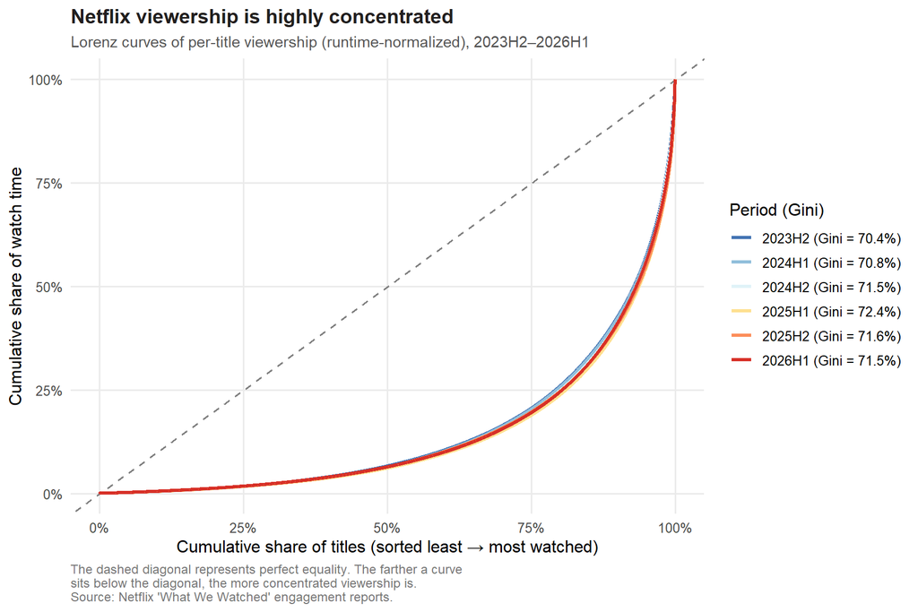

```r
lorenz_core <- NETFLIX_DATA |>
  filter(!is.na(runtime), runtime > 0, period != "2023H1") |>
  mutate(length_norm_views = hours_viewed / runtime) |>
  group_by(period) |>
  arrange(length_norm_views, .by_group = TRUE) |>
  mutate(
    rank_pct  = row_number() / n(),
    cum_share = cumsum(length_norm_views) / sum(length_norm_views)
  ) |>
  ungroup() |>
  select(period, rank_pct, cum_share)

anchors <- tibble(period = unique(lorenz_core$period), rank_pct = 0, cum_share = 0)

gini_labels <- gini_by_period |>
  filter(Period != "2023H1") |>
  mutate(Label = sprintf("%s (Gini = %.1f%%)",
                         Period, `Gini (length-normalized)` * 100)) |>
  select(period = Period, Label)

lorenz_data <- bind_rows(anchors, lorenz_core) |>
  left_join(gini_labels, by = "period") |>
  arrange(period, rank_pct)

ggplot(lorenz_data, aes(x = rank_pct, y = cum_share,
                        color = Label, group = period)) +
  geom_abline(slope = 1, intercept = 0, linetype = "dashed",
              color = "gray50", linewidth = 0.6) +
  geom_line(linewidth = 1.1) +
  scale_color_brewer(palette = "RdYlBu", direction = -1) +
  scale_x_continuous(labels = scales::percent_format(accuracy = 1)) +
  scale_y_continuous(labels = scales::percent_format(accuracy = 1)) +
  labs(
    title    = "Netflix viewership is highly concentrated",
    subtitle = "Lorenz curves of per-title viewership (runtime-normalized), 2023H2–2026H1",
    x        = "Cumulative share of titles (sorted least → most watched)",
    y        = "Cumulative share of watch time",
    color    = "Period (Gini)",
    caption  = paste0(
      "The dashed diagonal represents perfect equality. The farther a curve\n",
      "sits below the diagonal, the more concentrated viewership is.\n",
      "Source: Netflix 'What We Watched' engagement reports."
    )
  ) +
  theme_minimal(base_size = 12) +
  theme(
    plot.title       = element_text(face = "bold", size = 14, color = "#221F1F"),
    plot.subtitle    = element_text(size = 11, color = "#555555"),
    plot.caption     = element_text(size = 9, color = "#777777", hjust = 0),
    legend.position  = "right",
    panel.grid.minor = element_blank()
  )
```

## Supporting Calculations

All inline values used in the memo were computed in the `supporting-calculations` chunk at the top of this document (hidden via `#| include: false`). The Gini coefficient function and per-period Gini table are defined there as well, so all memo values refresh automatically when the data updates.